# Dashboard Design for a Varied Customer Base

2023-09-22

## Introduction

- **About CADEAS**
  - what we do, who our stakeholders are, what kind of products we make

## The challenges

- **Excel heavy**
  - Historically consisted of 8 separate Excel based weekly reports
  - Expected to be ‘publication ready’ within a tight timescale (around 2.5 hours) 😰😰😰
- **Business continuity**
  - A diverse range of stakeholders
  - Stakeholders mostly with limited exposure to R (primarily familiar with MS Office products such as Excel and PowerPoint)

## The challenges (continued)

- **Technical challenges**
  - Diverse geographical interests and policy driven requirements
  - Limited resource and time - no Shiny server hosting capacity (at least not yet)
  - Static PowerPoint slide style products were preferred over other innovative by some  
    Limited version controls on R, R Packages and the existing R scripts - results not reproducible

## The solution

- A Rmarkdown dashboard that is interactive, reproducible and user friendly (backward compatibility)
- Tips on how to cater to a wide range of audiences e.g. graphs and data, very clear tips, extract in multiple formats
- Workaround for the technical challenges
  - A combination use of R packages such as *flexdashboard*, *crosstalk*, *plotly*, *DT* and *flextable*
  - Minimal amount of Javascript and CSS to create an “illusion” of dependency dropdown 😵

## The solution (continued)

**Javascript** 😫

```javascript
$(document).ready(function() {
    document.getElementById("PTL_TS_Primary_Selection").getElementsByClassName("selectized")[0].selectize.removeOption("");
    document.getElementById("PTL_TS_Primary_Selection").getElementsByClassName("selectized")[0].selectize.setValue("National", false);
    document.getElementById("PTL_TS_Prov_Selection").getElementsByClassName("selectized")[0].selectize.removeOption("");
    document.getElementById("PTL_TS_Regional_Selection").getElementsByClassName("selectized")[0].selectize.removeOption("");
});

var ct_filter = new crosstalk.FilterHandle('PTL_TS');
$('#PTL_TS_Primary_Selection').on("change", function() {

if(document.getElementById("PTL_TS_Primary_Selection").getElementsByClassName("selectized")[0].value == "National"){
      document.getElementById("PTL_TS_Prov_Selection").getElementsByClassName("selectized")[0].selectize.setValue(null, false);
      document.getElementById("PTL_TS_Regional_Selection").getElementsByClassName("selectized")[0].selectize.setValue(null, false);
      document.getElementById("PTL_TS_Regional_Selection").style.display = "none";
      document.getElementById("PTL_TS_Prov_Selection").style.display = "none";
} else if(...
```

## The solution (continued)

[figure not shown]

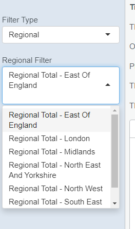

## Conclusion

- Summarise what we’ve said
- Questions